# Programme for International Student Assessment

## Bivariate Exploration

> In this section, investigate relationships between pairs of variables in your data. Make sure the variables that you cover here have been introduced in some fashion in the previous section (univariate exploration).

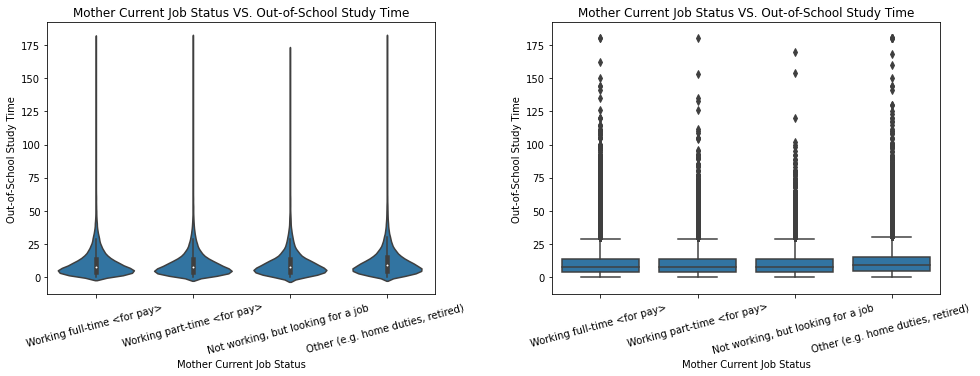

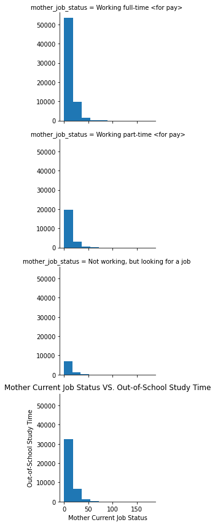

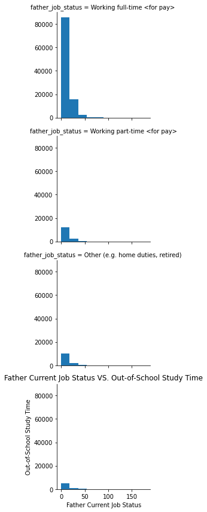

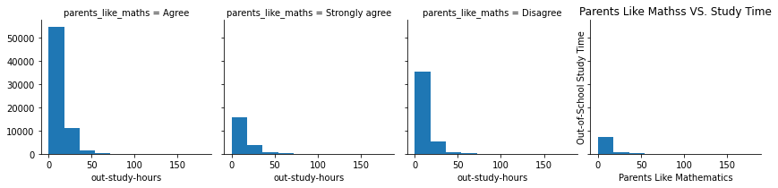

> Parents who like maths, their children study hours are more than the others.

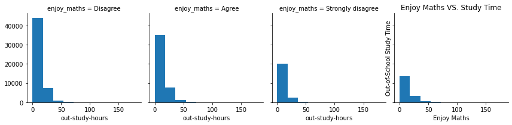

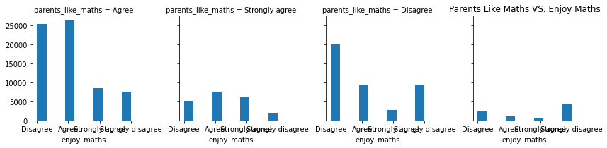

## Multivariate Exploration

> Create plots of three or more variables to investigate your data even further. Make sure that your investigations are justified, and follow from your work in the previous sections.

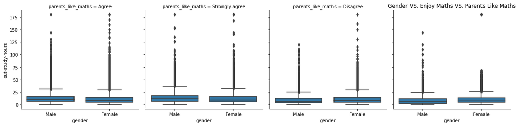

### Talk about some of the relationships you observed in this part of the investigation. Were there features that strengthened each other in terms of looking at your feature(s) of interest?

> I cannot really observe a relationship between gender, parents_like_maths, and out_study_hours variables.

### Were there any interesting or surprising interactions between features?

> No, I cannot observe any.